# AirPollution in particulates pm2.5 in US comparison 1999 and 2012

## Introduction

The data set I’m going to use right now for this example, comes from the U.S. Environmental Protection Agency and it involves air pollution monitoring data from the United States. In particular we’re looking at fine particulate matter air pollution that’s in the air. So particulate matter is, is just a fancy word for dust. So this is just dust that’s in the air and it’s it’s a, it’s of concern because we inhale air all the time.

So what we’re going to do is we’re going to look at data from 1999. And, and look at the fairly recent data from 2012. And I want to answer the very basic question. Are the levels on average lower in 2012 than they were in 1999?

```r
file.name <- "./RD_501_88101_1999-0.txt"
url       <- "https://archive.ics.uci.edu/ml/machine-learning-databases/00240/UCI%20HAR%20Dataset.zip"
zip.file  <- "./pm25_data.zip"

if (!file.exists(file.name)) {
  #download.file(url, destfile = zip.file)
  unzip(zip.file)
  #file.remove(zip.file)
}

## Read in data from 1999

pm0 <- read.table("pm25_data/RD_501_88101_1999-0.txt", comment.char = "#", header = FALSE, sep = "|", na.strings = "")
dim(pm0)
```

```
## [1] 117421     28
```

```r
head(pm0)
```

```
##   V1 V2 V3 V4 V5    V6 V7 V8  V9 V10      V11   V12    V13  V14 V15 V16
## 1 RD  I  1 27  1 88101  1  7 105 120 19990103 00:00     NA   AS   3  NA
## 2 RD  I  1 27  1 88101  1  7 105 120 19990106 00:00     NA   AS   3  NA
## 3 RD  I  1 27  1 88101  1  7 105 120 19990109 00:00     NA   AS   3  NA
## 4 RD  I  1 27  1 88101  1  7 105 120 19990112 00:00  8.841 <NA>   3  NA
## 5 RD  I  1 27  1 88101  1  7 105 120 19990115 00:00 14.920 <NA>   3  NA
## 6 RD  I  1 27  1 88101  1  7 105 120 19990118 00:00  3.878 <NA>   3  NA
##    V17 V18 V19 V20 V21 V22 V23 V24 V25 V26 V27 V28
## 1 <NA>  NA  NA  NA  NA  NA  NA  NA  NA  NA  NA  NA
## 2 <NA>  NA  NA  NA  NA  NA  NA  NA  NA  NA  NA  NA
## 3 <NA>  NA  NA  NA  NA  NA  NA  NA  NA  NA  NA  NA
## 4 <NA>  NA  NA  NA  NA  NA  NA  NA  NA  NA  NA  NA
## 5 <NA>  NA  NA  NA  NA  NA  NA  NA  NA  NA  NA  NA
## 6 <NA>  NA  NA  NA  NA  NA  NA  NA  NA  NA  NA  NA
```

```r
cnames <- readLines("pm25_data/RD_501_88101_1999-0.txt", 1)
print(cnames)
```

```
## [1] "# RD|Action Code|State Code|County Code|Site ID|Parameter|POC|Sample Duration|Unit|Method|Date|Start Time|Sample Value|Null Data Code|Sampling Frequency|Monitor Protocol (MP) ID|Qualifier - 1|Qualifier - 2|Qualifier - 3|Qualifier - 4|Qualifier - 5|Qualifier - 6|Qualifier - 7|Qualifier - 8|Qu…
```

```r
cnames <- strsplit(cnames, "|", fixed = TRUE)
print(cnames)
```

```
## [[1]]
##  [1] "# RD"
##  [2] "Action Code"
##  [3] "State Code"
##  [4] "County Code"
##  [5] "Site ID"
##  [6] "Parameter"
##  [7] "POC"
##  [8] "Sample Duration"
##  [9] "Unit"
## [10] "Method"
## [11] "Date"
## [12] "Start Time"
## [13] "Sample Value"
## [14] "Null Data Code"
## [15] "Sampling Frequency"
## [16] "Monitor Protocol (MP) ID"
## [17] "Qualifier - 1"
## [18] "Qualifier - 2"
## [19] "Qualifier - 3"
## [20] "Qualifier - 4"
## [21] "Qualifier - 5"
## [22] "Qualifier - 6"
## [23] "Qualifier - 7"
## [24] "Qualifier - 8"
## [25] "Qualifier - 9"
## [26] "Qualifier - 10"
## [27] "Alternate Method Detectable Limit"
## [28] "Uncertainty"
```

```r
names(pm0) <- make.names(cnames[[1]])
head(pm0)
```

```
##   X..RD Action.Code State.Code County.Code Site.ID Parameter POC
## 1    RD           I          1          27       1     88101   1
## 2    RD           I          1          27       1     88101   1
## 3    RD           I          1          27       1     88101   1
## 4    RD           I          1          27       1     88101   1
## 5    RD           I          1          27       1     88101   1
## 6    RD           I          1          27       1     88101   1
##   Sample.Duration Unit Method     Date Start.Time Sample.Value
## 1               7  105    120 19990103      00:00           NA
## 2               7  105    120 19990106      00:00           NA
## 3               7  105    120 19990109      00:00           NA
## 4               7  105    120 19990112      00:00        8.841
## 5               7  105    120 19990115      00:00       14.920
## 6               7  105    120 19990118      00:00        3.878
##   Null.Data.Code Sampling.Frequency Monitor.Protocol..MP..ID Qualifier...1
```

[output cut: 27 more lines]

```r
x0 <- pm0$Sample.Value
class(x0)
```

```
## [1] "numeric"
```

```r
str(x0)
```

```
##  num [1:117421] NA NA NA 8.84 14.92 ...
```

```r
summary(x0)
```

```
##    Min. 1st Qu.  Median    Mean 3rd Qu.    Max.    NA's
##    0.00    7.20   11.50   13.74   17.90  157.10   13217
```

```r
mean(is.na(x0))  ## Are missing values important here?
```

```
## [1] 0.1125608
```

```r
## Read in data from 2012

pm1 <- read.table("pm25_data/RD_501_88101_2012-0.txt", comment.char = "#", header = FALSE, sep = "|", na.strings = "", nrow = 1304290)
names(pm1) <- make.names(cnames[[1]])
head(pm1)
```

```
##   X..RD Action.Code State.Code County.Code Site.ID Parameter POC
## 1    RD           I          1           3      10     88101   1
## 2    RD           I          1           3      10     88101   1
## 3    RD           I          1           3      10     88101   1
## 4    RD           I          1           3      10     88101   1
## 5    RD           I          1           3      10     88101   1
## 6    RD           I          1           3      10     88101   1
##   Sample.Duration Unit Method     Date Start.Time Sample.Value
## 1               7  105    118 20120101      00:00          6.7
## 2               7  105    118 20120104      00:00          9.0
## 3               7  105    118 20120107      00:00          6.5
## 4               7  105    118 20120110      00:00          7.0
## 5               7  105    118 20120113      00:00          5.8
## 6               7  105    118 20120116      00:00          8.0
##   Null.Data.Code Sampling.Frequency Monitor.Protocol..MP..ID Qualifier...1
```

[output cut: 27 more lines]

```r
dim(pm1)
```

```
## [1] 1304287      28
```

```r
x1 <- pm1$Sample.Value
class(x1)
```

```
## [1] "numeric"
```

Lets do our first quick comparison.It seems that at least in the median it has decrease the volume of fine particulates. We see also that the percentage of missing value has decrease from 11% to 5%

```r
summary(x0)
```

```
##    Min. 1st Qu.  Median    Mean 3rd Qu.    Max.    NA's
##    0.00    7.20   11.50   13.74   17.90  157.10   13217
```

```r
summary(x1)
```

```
##    Min. 1st Qu.  Median    Mean 3rd Qu.    Max.    NA's
##  -10.00    4.00    7.63    9.14   12.00  908.97   73133
```

```r
mean(is.na(x0))
```

```
## [1] 0.1125608
```

```r
mean(is.na(x1))
```

```
## [1] 0.05607125
```

The next thing is to look at the boxplot. If we see first former results we detect that the maximun in 2012 is very hight compared to maximun in 1999, so if we plot this it seems both graphs are a bit skewed, so we can make use of log10 function to avoid this maximun.

The black line, which was the median of this box, that does go down quite a bit. Remember, this is on a log scale, so even a small change can be a big change in the absolute scale. But one thing that you’ll notice is that the spread of the data has also increased too. So even though the average levels have gone down, there are more kind of extreme values in the later data.

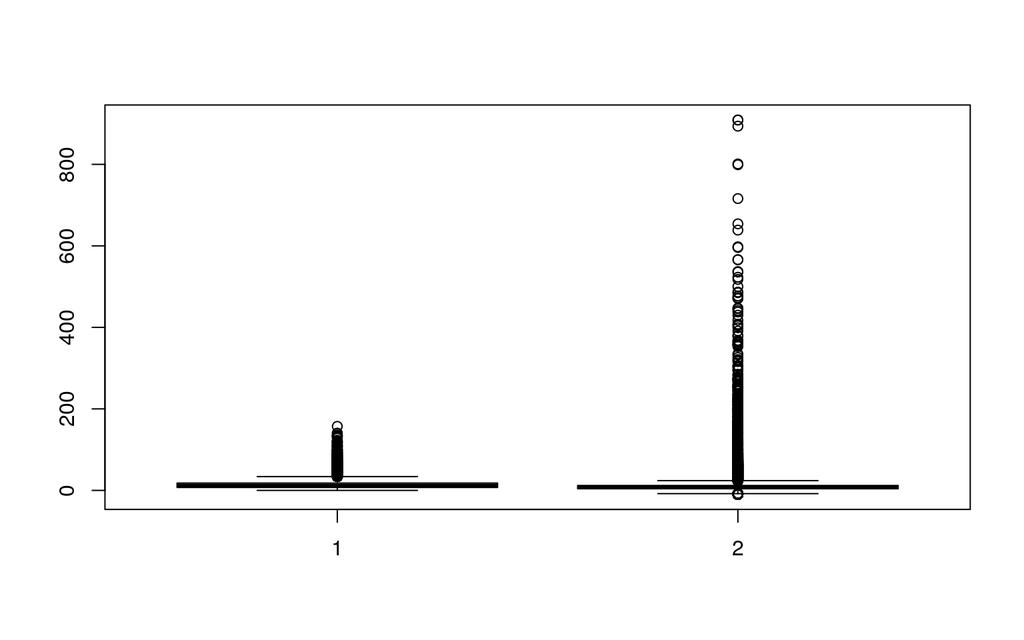

```r
boxplot(x0, x1)
```

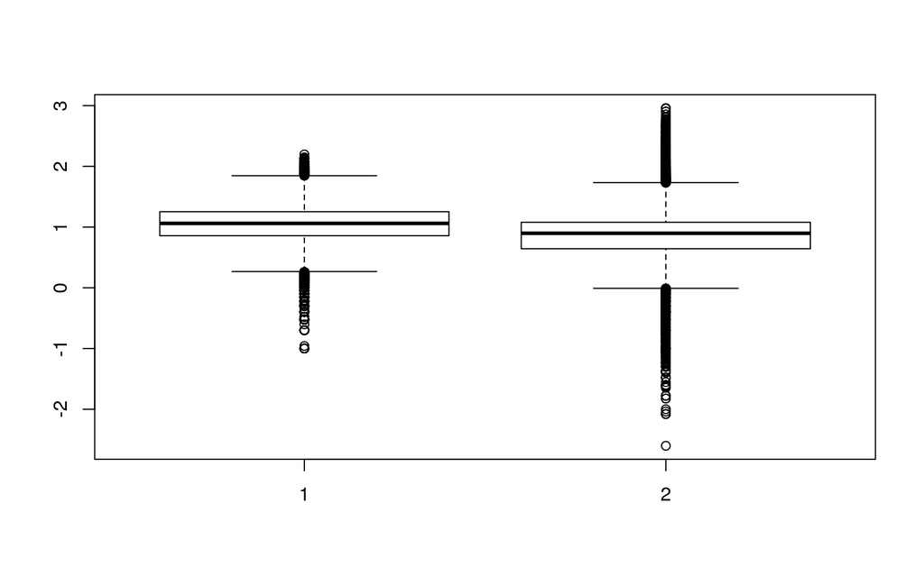

```r
boxplot(log10(x0), log10(x1))
```

The next thing we need to deal with is the negative values. It is impossible to have negative values here. We will look at it by months to detect if there is any pattern related to the date.

```r
## Check negative values in 'x1'
summary(x1)
```

```
##    Min. 1st Qu.  Median    Mean 3rd Qu.    Max.    NA's
##  -10.00    4.00    7.63    9.14   12.00  908.97   73133
```

```r
negative <- x1 < 0
sum(negative, na.rm = T)
```

```
## [1] 26474
```

```r
mean(negative, na.rm = T)
```

```
## [1] 0.0215034
```

```r
dates <- pm1$Date
str(dates)
```

```
##  int [1:1304287] 20120101 20120104 20120107 20120110 20120113 20120116 20120119 20120122 20120125 20120128 ...
```

```r
dates <- as.Date(as.character(dates), "%Y%m%d")
str(dates)
```

```
##  Date[1:1304287], format: "2012-01-01" "2012-01-04" "2012-01-07" "2012-01-10" "2012-01-13" ...
```

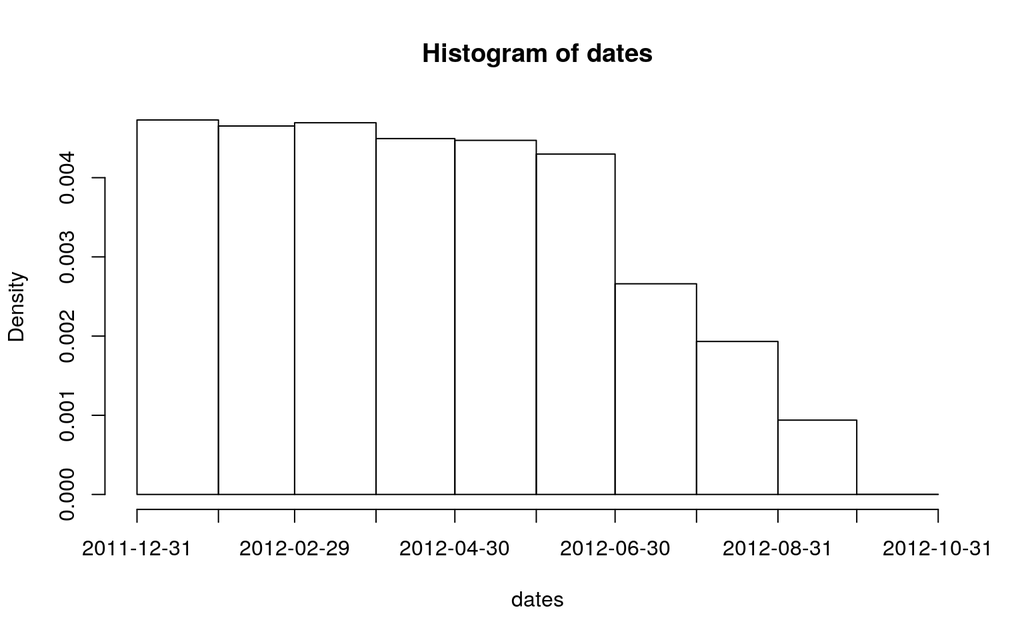

```r
hist(dates, "month")  ## Check what's going on in months 1--6, we see that the first months of the year is where there is more fine particulates
```

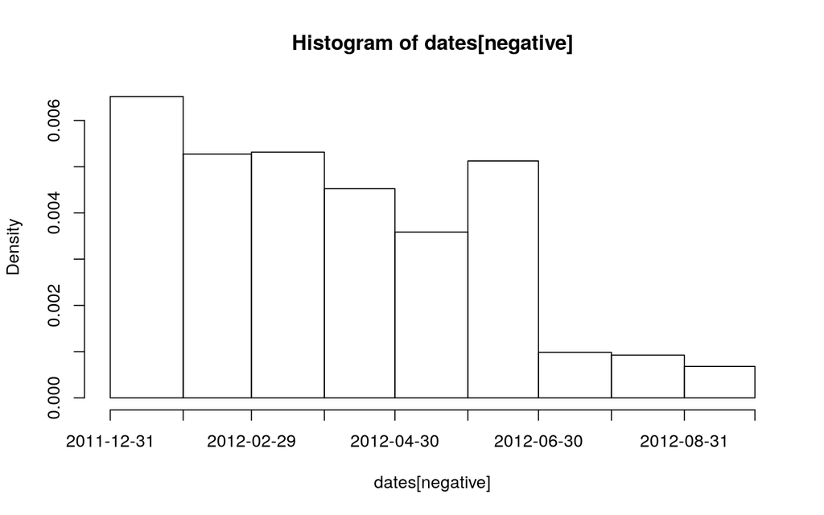

```r
hist(dates[negative], "month")  ## Check what's going on in months 1--6
```

Lets take a look at a particular city, New York for example. We first must identify if in there exist monitors in both years. There is 10 monitors in New York with data in both years.

```r
site0 <- unique(subset(pm0, State.Code == 36, c(County.Code, Site.ID)))
site1 <- unique(subset(pm1, State.Code == 36, c(County.Code, Site.ID)))
site0 <- paste(site0[,1], site0[,2], sep = ".")
site1 <- paste(site1[,1], site1[,2], sep = ".")
str(site0)
```

```
##  chr [1:33] "1.5" "1.12" "5.73" "5.80" "5.83" "5.110" "13.11" ...
```

```r
str(site1)
```

```
##  chr [1:18] "1.5" "1.12" "5.80" "5.133" "13.11" "29.5" "31.3" "47.122" ...
```

```r
both <- intersect(site0, site1)
print(both)
```

```
##  [1] "1.5"     "1.12"    "5.80"    "13.11"   "29.5"    "31.3"    "63.2008"
##  [8] "67.1015" "85.55"   "101.3"
```

Lets create a new variable called country.site to count how many observations do we have from each monitor in the state of New York

```r
pm0$county.site <- with(pm0, paste(County.Code, Site.ID, sep = "."))
pm1$county.site <- with(pm1, paste(County.Code, Site.ID, sep = "."))
cnt0 <- subset(pm0, State.Code == 36 & county.site %in% both)
cnt1 <- subset(pm1, State.Code == 36 & county.site %in% both)
sapply(split(cnt0, cnt0$county.site), nrow)
```

```
##   101.3    1.12   13.11     1.5    29.5    31.3    5.80 63.2008 67.1015
##     152      61      61     122      61     183      61     122     122
##   85.55
##       7
```

```r
sapply(split(cnt1, cnt1$county.site), nrow)
```

```
##   101.3    1.12   13.11     1.5    29.5    31.3    5.80 63.2008 67.1015
##      31      31      31      64      33      15      31      30      31
##   85.55
##      31
```

Now we are going to choose just one of those monitors

```r
## Choose county 63 and side ID 2008
pm1sub <- subset(pm1, State.Code == 36 & County.Code == 63 & Site.ID == 2008)
pm0sub <- subset(pm0, State.Code == 36 & County.Code == 63 & Site.ID == 2008)
dim(pm1sub)
```

```
## [1] 30 29
```

```r
dim(pm0sub)
```

```
## [1] 122  29
```

We have now the same monitor, lets plot the particulates along the time from both years, first for 1999

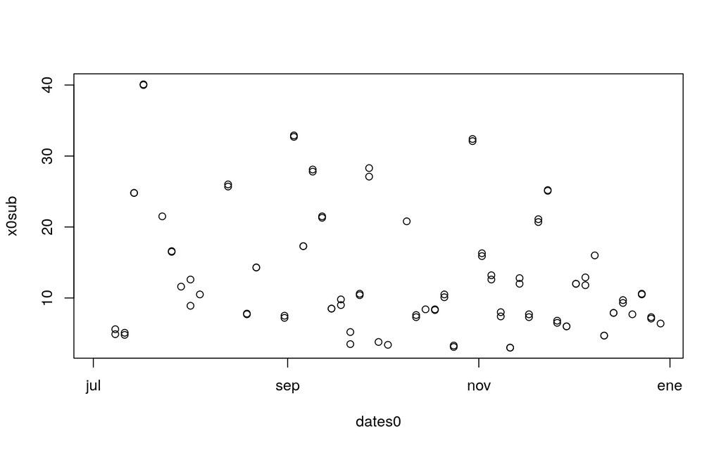

```r
## Plot data for 1999
dates0 <- pm0sub$Date
dates0 <- as.Date(as.character(dates0), "%Y%m%d")
x0sub <- pm0sub$Sample.Value
plot(dates0, x0sub)
```

And now for 2012

```r
## Plot data for 2012
dates1 <- pm1sub$Date
x1sub <- pm1sub$Sample.Value
dates1 <- as.Date(as.character(dates1), "%Y%m%d")
str(dates1)
```

```
##  Date[1:30], format: "2012-01-01" "2012-01-04" "2012-01-07" "2012-01-10" "2012-01-13" ...
```

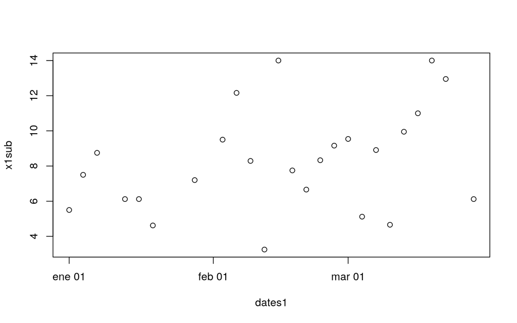

```r
plot(dates1, x1sub)
```

And now boths in the same pannel, here we can observe an error that could lead to missundertand the data, it seems the mean in 2012 in bigger than in 1999 when it results that the graphs have different range.

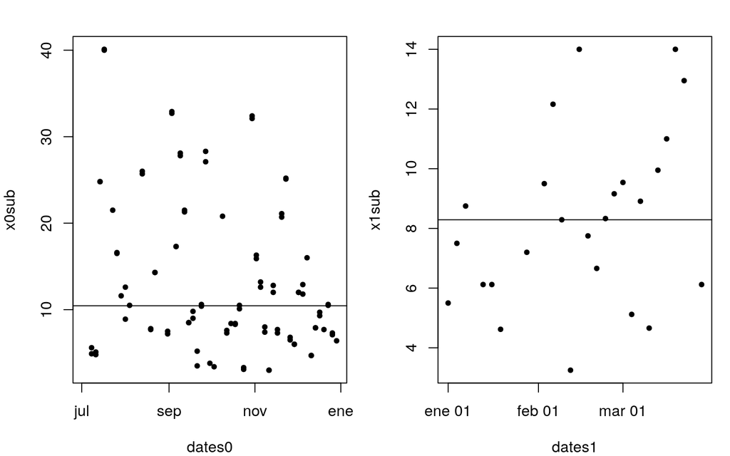

```r
## Plot data for both years in same panel
par(mfrow = c(1, 2), mar = c(4, 4, 2, 1))
plot(dates0, x0sub, pch = 20)
abline(h = median(x0sub, na.rm = T))
plot(dates1, x1sub, pch = 20)  ## Whoa! Different ranges
abline(h = median(x1sub, na.rm = T))
```

Now the range is correct, and we can observe the mean value is lower in 2012 than in 1999. There is also a very curious thing, that is the data in 1999 is much more spread than in 2012 which is much less variable, so there is much less days with spikes of particulates

```r
## Find global range
rng <- range(x0sub, x1sub, na.rm = T)
rng
```

```
## [1]  3.0 40.1
```

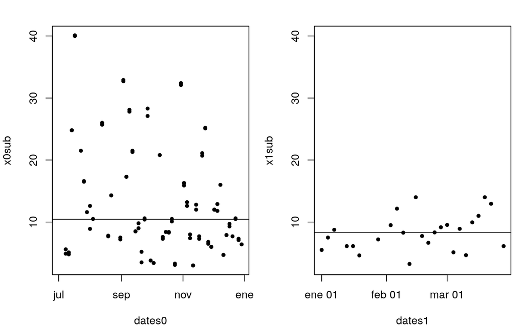

```r
par(mfrow = c(1, 2), mar = c(4, 4, 2, 1))
plot(dates0, x0sub, pch = 20, ylim = rng)
abline(h = median(x0sub, na.rm = T))
plot(dates1, x1sub, pch = 20, ylim = rng)
abline(h = median(x1sub, na.rm = T))
```

```r
## Show state-wide means and make a plot showing trend
head(pm0)
```

```
##   X..RD Action.Code State.Code County.Code Site.ID Parameter POC
## 1    RD           I          1          27       1     88101   1
## 2    RD           I          1          27       1     88101   1
## 3    RD           I          1          27       1     88101   1
## 4    RD           I          1          27       1     88101   1
## 5    RD           I          1          27       1     88101   1
## 6    RD           I          1          27       1     88101   1
##   Sample.Duration Unit Method     Date Start.Time Sample.Value
## 1               7  105    120 19990103      00:00           NA
## 2               7  105    120 19990106      00:00           NA
## 3               7  105    120 19990109      00:00           NA
## 4               7  105    120 19990112      00:00        8.841
## 5               7  105    120 19990115      00:00       14.920
## 6               7  105    120 19990118      00:00        3.878
##   Null.Data.Code Sampling.Frequency Monitor.Protocol..MP..ID Qualifier...1
```

[output cut: 27 more lines]

```r
mn0 <- with(pm0, tapply(Sample.Value, State.Code, mean, na.rm = T))
str(mn0)
```

```
##  num [1:53(1d)] 19.96 6.67 10.8 15.68 17.66 ...
##  - attr(*, "dimnames")=List of 1
##   ..$ : chr [1:53] "1" "2" "4" "5" ...
```

```r
summary(mn0)
```

```
##    Min. 1st Qu.  Median    Mean 3rd Qu.    Max.
##   4.862   9.519  12.315  12.406  15.640  19.956
```

```r
mn1 <- with(pm1, tapply(Sample.Value, State.Code, mean, na.rm = T))
str(mn1)
```

```
##  num [1:52(1d)] 10.13 4.75 8.61 10.56 9.28 ...
##  - attr(*, "dimnames")=List of 1
##   ..$ : chr [1:52] "1" "2" "4" "5" ...
```

```r
## Make separate data frames for states / years
d0 <- data.frame(state = names(mn0), mean = mn0)
d1 <- data.frame(state = names(mn1), mean = mn1)
mrg <- merge(d0, d1, by = "state")
dim(mrg)
```

```
## [1] 52  3
```

```r
head(mrg)
```

```
##   state    mean.x    mean.y
## 1     1 19.956391 10.126190
## 2    10 14.492895 11.236059
## 3    11 15.786507 11.991697
## 4    12 11.137139  8.239690
## 5    13 19.943240 11.321364
## 6    15  4.861821  8.749336
```

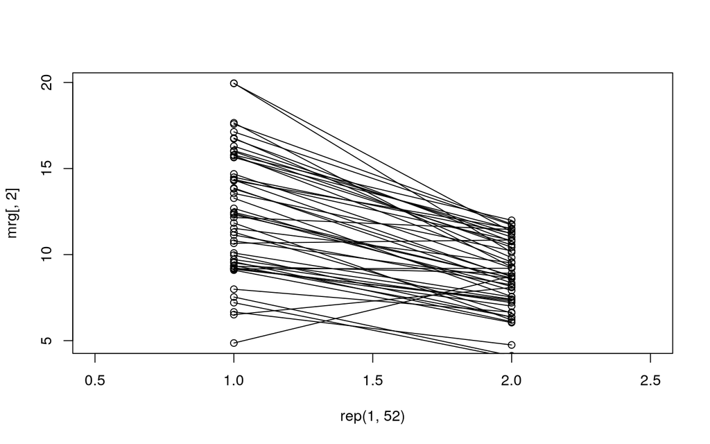

```r
## Connect lines
par(mfrow = c(1, 1))
with(mrg, plot(rep(1, 52), mrg[, 2], xlim = c(.5, 2.5)))
with(mrg, points(rep(2, 52), mrg[, 3]))
segments(rep(1, 52), mrg[, 2], rep(2, 52), mrg[, 3])
```

Miguel Ángel Huerta

6 de abril de 2019